# Segmentation Analysis

## Segmentation Analysis

This script opens and analyses the segmentation task: 1) open csv file and store as a data.frame 2) organize data in data.frame to extract keypresses 3) get a frequency of key presses for each video per participant Note: removed subject 28303

To-do:

Questions for Savannah:

- What are the properties of the three videos? Properties?
- Which video should we use for analysis? all 3
- How did Anna use the videos? frequency of event segmentation was assessed across all 3 videos
- Which brain regions corresponding to EEG electrode placement is relevant to look at for longterm/episodic memory and working memory? –> 01 & 02 for EEG alpha
- Individual electrode powers or networks? Individual - according to Chantel

```r
#rm(list = ls())
library(jsonlite)
library(stringr)
library(matlab)
library(tidyverse)
library(reshape2)
library(gridExtra)
```

```r
#
subject = c()
#read data file
data.files <- list.files('raw_data/', pattern = '.csv')

n.participants <- length(data.files)
n.videos <- 3 # participants watch 3 videos
#initialize variable
subject.segs <- c()
subject.vid.ord <- c()
subject.keyPresses <- list()
subject.keyPresses.v1 <- list()
subject.keyPresses.v2 <- list()
subject.keyPresses.v3 <- list()
#loop through all participants
i = 1
for (p in data.files) {
subject[i] = str_sub(p, 1,5) %>% as.numeric()
seg.data = read.csv(file = paste0('raw_data/', p))
#What keys were pressed
#What and when event happend (when did the instructions end, when did the videos start etc)
#When were the keys pressed by participant
#How long are the videos?
vid.length =c(201, 210, 237) #video lengths in seconds for v1, v5, and v7
##  extracting data from the segmentation data file
#first use a pattern to find the reaction times
pattern = "[0-9]"
#use regExp function grep to exrtact the reaction times
  #grep(pattern,seg.data$key_resp1_seg.rt, value = TRUE)
# use fromJSON function to convert to numerical data
#fromJSON(grep(pattern,seg.data$key_resp1_seg.rt, value = TRUE))


#parse log for end times - we could have probably just done this by eye but that's not fun...
#read in log file
log.temp <- read.delim(file =  paste0('raw_data/', substring(p, 1, str_length(p) - 3),'log'),
                       header = F, sep = "\t")

vid1.i <- str_detect(log.temp$V3, 'movie1_video: movie') #find entry for video 1
vid2.i <- str_detect(log.temp$V3, 'movie2_video: movie') #find entry for video 2
vid3.i <- str_detect(log.temp$V3, 'movie3_seg: movie')   #find entry for video 3

vid1 <- substring(log.temp$V3[vid1.i], 20,50) %>% str_extract(., "v.")
vid2 <- substring(log.temp$V3[vid2.i], 20,50) %>% str_extract(., "v.")
vid3 <- substring(log.temp$V3[vid3.i], 20,50) %>% str_extract(., "v.")

subject.vid.ord<- c(subject.vid.ord, vid1, vid2, vid3)

vid1.segments.rt <-  c(0, fromJSON(grep(pattern, seg.data$key_resp1_seg.rt, value = TRUE)))
vid2.segments.rt <-  c(0, fromJSON(grep(pattern, seg.data$key_resp2_seg.rt, value = TRUE)))
vid3.segments.rt <-  c(0, fromJSON(grep(pattern, seg.data$key_resp3_seg.rt, value = TRUE)))

#Find and exclude rapid key presses
subject.segs <- c(subject.segs,
                     length(vid1.segments.rt) - sum(diff(vid1.segments.rt) < .1),
                     length(vid2.segments.rt) - sum(diff(vid2.segments.rt) < .1),
                     length(vid3.segments.rt) - sum(diff(vid3.segments.rt) < .1))


#save all key presses
subject.keyPresses[i] <-  list(list(vid1.segments.rt,vid2.segments.rt,vid3.segments.rt))
subject.keyPresses.v1[i] <-  list(vid1.segments.rt)
subject.keyPresses.v2[i] <-  list(vid2.segments.rt)
subject.keyPresses.v3[i] <-  list(vid3.segments.rt)

i = i+1
}
subject.segments.tmp <- subject.segs %>% as.matrix() %>% reshape(., n.videos, n.participants) %>% t()
subject.vid.order <- subject.vid.ord %>% as.matrix() %>%  reshape(., n.videos, n.participants) %>% t()

#m[order(m[,1]),]
#Sort segmentation in order of V1, V5, V7
subject.segments.ord = c()

for (r in c(1:n.participants)) {

subject.segments.ord <- c(subject.segments.ord, subject.segments.tmp[r, order(subject.vid.order[r, ])])
}


subject.segments <- data.frame('subject' = subject,
                                'V' = subject.segments.ord %>% as.matrix() %>% reshape(.,  n.videos, n.participants) %>% t()
                                )

if(0) {
  write.csv(subject.segments,'./processed/segmentation_by_subject.csv',row.names = F)
}
```

## raster plots

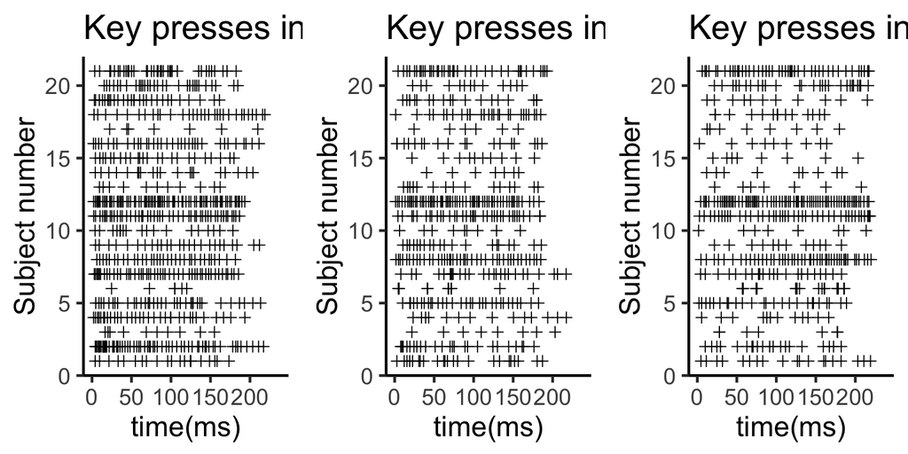

```r
fig.v3 <- subject.keyPresses.v3 %>% melt() %>% ggplot(aes(value, L1)) + geom_point(shape=3, size=2) +
  xlab('time(ms)') + ylab('Subject number') +
  theme_classic(base_size = 18) + xlim(c(1,237)) +
  labs(title='Key presses in Video 3(v7)')

fig.v2 <-subject.keyPresses.v2 %>% melt() %>% ggplot(aes(value, L1)) + geom_point(shape=3, size=2) +
  xlab('time(ms)') + ylab('Subject number') +
  theme_classic(base_size = 18) + xlim(c(1,237)) +
  labs(title='Key presses in Video 2(v5)')

fig.v1 <- subject.keyPresses.v1 %>% melt() %>% ggplot(aes(value, L1)) + geom_point(shape=3, size=2) +
  xlab('time(ms)') + ylab('Subject number') +
  theme_classic(base_size = 18) + xlim(c(1,237)) +
  labs(title='Key presses in Video 1(v1)')

grid.arrange(fig.v1,fig.v2,fig.v3, nrow = 1, ncol = 3)
```

## Notes on EEG from Malayka

- EEG data starts at pink column
- Data starts with theta
- **Power**:amplitude of waveform within a given freq. band.
- anatomy of a column title :*electrodeLocation_freq.band_power/coh_training_peak-standard_eyesclosed*
- IAF : individualALPHAFrequency
- Odd numbered channels are always on the left
- Laterality is the inter-hemispheric difference in power
- LeftFrontoTemporal, RFT, RPosterior, LateralParietal, MedialFrontal
- Start with O1 and O2 which have the highest alpha power. Correlate with measures of interest.